# DataTest

Guanzhong You

Apr 2, 2017

# Question 1

| Dataset | Method | Focus | n | p |
| --- | --- | --- | --- | --- |
| (a)Salary | Regression | Inference | 350 | 3 |
| (b)Product | Classification | Prediction | 31 | 13 |
| (c)Stock | Regression | Prediction | 52 | 3 |

1. This is a regression problem because salary is a continuous variable. It focuses on inference because we want only to figure out influential factors but not to predict.
2. This is a classification problem because response variable (Success/Fail) is a categorical variable. It focuses on prediction because the aim is to forecast the market reaction of a new product instead of to tell which factor influence a historical product’s destiny. This problem may need feature selection or it will suffer from overfitting.
3. This is a regression problem because % change in dollar is a continuous variable. It focuses on prediction because the target is to tell the change of dollar given stock market information, not to analyze which stock market affect dollar most. This problem may employ elastic logarithm model.

# Question 2

## 1.Read Data

- Import packages
- Set working directory
- Read in data

```r
library(dplyr)
library(plotly)
library(Hmisc)
library(psych)
library(MASS)
library(caret)
library(pROC)
library(xgboost)
library(AER)
setwd("C:/Users/Administrator/Desktop/test/data-analyst-data-test-master/data-analyst-data-test-master")
RawData = read.csv("Cars_mileage.csv",stringsAsFactors = F)
head(RawData,n=6)
```

```
##   mpg cylinders displacement horsepower weight acceleration year origin
## 1  18         8          307        130   3504         12.0   70      1
## 2  15         8          350        165   3693         11.5   70      1
## 3  18         8          318        150   3436         11.0   70      1
## 4  16         8          304        150   3433         12.0   70      1
## 5  17         8          302        140   3449         10.5   70      1
## 6  15         8          429        198   4341         10.0   70      1
##                        name
## 1 chevrolet chevelle malibu
## 2         buick skylark 320
## 3        plymouth satellite
## 4             amc rebel sst
## 5               ford torino
## 6          ford galaxie 500
```

## 2.Data Manipulation (Question 2.(a) Included)

- Create varible mpg_binary as required in Question 2.(a)
- Create more potentially useful variables:
  - **brand**: Different brands may have different design thinking in fuel efficiency. Most car’s name starts with its brand name, so it’s easy to seperate that apart.
  - **gpm**: gallon per mile, whcih looks more like a variable that has a linear relation with other variables. E.g., one ton increase in weight could increase gpm by a certain amount.
  - **sw**: whether it is Station Wagon. This is marked with(sw) after each car’s name. Station Wagon may have a different fuel efficiency pattern compared to sedan, since its shape and structure is different.
- Omit some NA data. Some rows has a “?” mark in horsepower. The number of those rows is very small so it is safe to simple delete those entries. No need for imputation, which brings in biases.
- Change the sign of origin. The origin is marked with number. For further interpretation, I changed it to area name.

```r
MedianMPG = median(RawData$mpg)
mpg_binary=as.integer(mpg>MedianMPG) # Question 2.(a) Here
CarData = RawData %>%
          mutate(horsepower=as.integer(horsepower)) %>%
          filter(!is.na(horsepower)) %>%
          mutate(mpg_binary=as.integer(mpg>MedianMPG)) %>%
          mutate(brand=
                   (regexpr(" ",name)-1)%>%
                   ifelse((.==-2),nchar(name),.)%>%
                   substr(x=name,start=1,stop=.))%>%
          mutate(gpm=1/mpg)%>%
          mutate(sw=grepl(pattern="\\(sw\\)",name))
sumTable=CarData %>%
         group_by(as.factor(brand)) %>%
         summarise(n=n())%>%
         arrange(n)
head(CarData)
```

```
##   mpg cylinders displacement horsepower weight acceleration year origin
## 1  18         8          307        130   3504         12.0   70      1
## 2  15         8          350        165   3693         11.5   70      1
## 3  18         8          318        150   3436         11.0   70      1
## 4  16         8          304        150   3433         12.0   70      1
## 5  17         8          302        140   3449         10.5   70      1
## 6  15         8          429        198   4341         10.0   70      1
##                        name mpg_binary     brand        gpm    sw
## 1 chevrolet chevelle malibu          0 chevrolet 0.05555556 FALSE
## 2         buick skylark 320          0     buick 0.06666667 FALSE
## 3        plymouth satellite          0  plymouth 0.05555556 FALSE
## 4             amc rebel sst          0       amc 0.06250000 FALSE
## 5               ford torino          0      ford 0.05882353 FALSE
## 6          ford galaxie 500          0      ford 0.06666667 FALSE
```

```r
print(sumTable,n=38)
```

```
## # A tibble: 37 × 2
##    `as.factor(brand)`     n
##                <fctr> <int>
## 1               capri     1
## 2           chevroelt     1
## 3                  hi     1
## 4            mercedes     1
## 5              nissan     1
## 6             toyouta     1
## 7             triumph     1
## 8           vokswagen     1
## 9                 bmw     2
## 10           cadillac     2
## 11              maxda     2
## 12      mercedes-benz     2
```

[output cut: 25 more lines]

From above I found some typo in brand name. In addition, names of some cars contains only model name, instead of starting with a brand name. I searched the internet and found their brand names and mannually inserted. Following codes solve this problem.

```r
attach(CarData)
  brand[brand=="capri"]="ford"
  brand[brand=="chevroelt"]="chevrolet"
  brand[brand=="vokswagen"]="volkswagen"
  brand[brand=="mercedes-benz"]="mercedes"
  brand[brand=="chevroelt"]="chevrolet"
  brand[brand=="hi"]="unknown"
  brand[brand=="triumph"]="unknown"
  brand[brand=="bmw"]="unknown"
  brand[brand=="toyouta"]="toyota"
  brand[brand=="cadillac"]="unknown"
  brand[brand=="maxda"]="mazda"
  brand[brand=="chevy"]="chevrolet"
  brand[brand=="opel"]="unknown"
  brand[brand=="saab"]="unknown"
  brand[brand=="subaru"]="unknown"
  brand[brand=="chrysler"]="unknown"
  brand[brand=="volvo"]="unknown"
  brand[brand=="vw"]="unknown"
  brand[brand=="audi"]="unknown"
  brand[brand=="fiat"]="unknown"
  brand[brand=="peugeot"]="unknown"
  brand[brand=="mercury"]="ford"
  brand[brand=="mercedes"]="unknown"
  brand[brand=="renault"]="unknown"
  brand[brand=="datsun"]="nissan"
  origin[origin==1]="American"
  origin[origin==2]="European"
  origin[origin==3]="Japan"
  CarData$brand=capitalize(brand)
  CarData$origin=factor(origin)
detach(CarData)
sumTable=CarData %>%
         group_by(brand) %>%
         summarise(n=n(),avg_mpg=mean(mpg))%>%
         arrange(avg_mpg)
CarData$brand=factor(CarData$brand,levels=sumTable$`brand`,ordered = T)
print(sumTable,n=14)
```

```
## # A tibble: 14 × 3
##         brand     n  avg_mpg
##         <chr> <int>    <dbl>
## 1         Amc    27 18.07037
## 2       Buick    17 19.18235
## 3        Ford    60 19.50167
## 4     Pontiac    16 20.01250
## 5   Chevrolet    47 20.21915
## 6  Oldsmobile    10 21.10000
## 7    Plymouth    31 21.70323
## 8       Dodge    28 22.06071
## 9     Unknown    65 25.92000
## 10     Toyota    26 28.16538
## 11 Volkswagen    16 29.15000
## 12      Mazda    12 30.05833
## 13     Nissan    24 31.31667
## 14      Honda    13 33.76154
```

```r
head(CarData)
```

```
##   mpg cylinders displacement horsepower weight acceleration year   origin
## 1  18         8          307        130   3504         12.0   70 American
## 2  15         8          350        165   3693         11.5   70 American
## 3  18         8          318        150   3436         11.0   70 American
## 4  16         8          304        150   3433         12.0   70 American
## 5  17         8          302        140   3449         10.5   70 American
## 6  15         8          429        198   4341         10.0   70 American
##                        name mpg_binary     brand        gpm    sw
## 1 chevrolet chevelle malibu          0 Chevrolet 0.05555556 FALSE
## 2         buick skylark 320          0     Buick 0.06666667 FALSE
## 3        plymouth satellite          0  Plymouth 0.05555556 FALSE
## 4             amc rebel sst          0       Amc 0.06250000 FALSE
## 5               ford torino          0      Ford 0.05882353 FALSE
## 6          ford galaxie 500          0      Ford 0.06666667 FALSE
```

Now the data looks much tidier.

## 3. Feature Exploration (Question 2.(b) Included)

First, of course, we want to know the correlation between different variables.

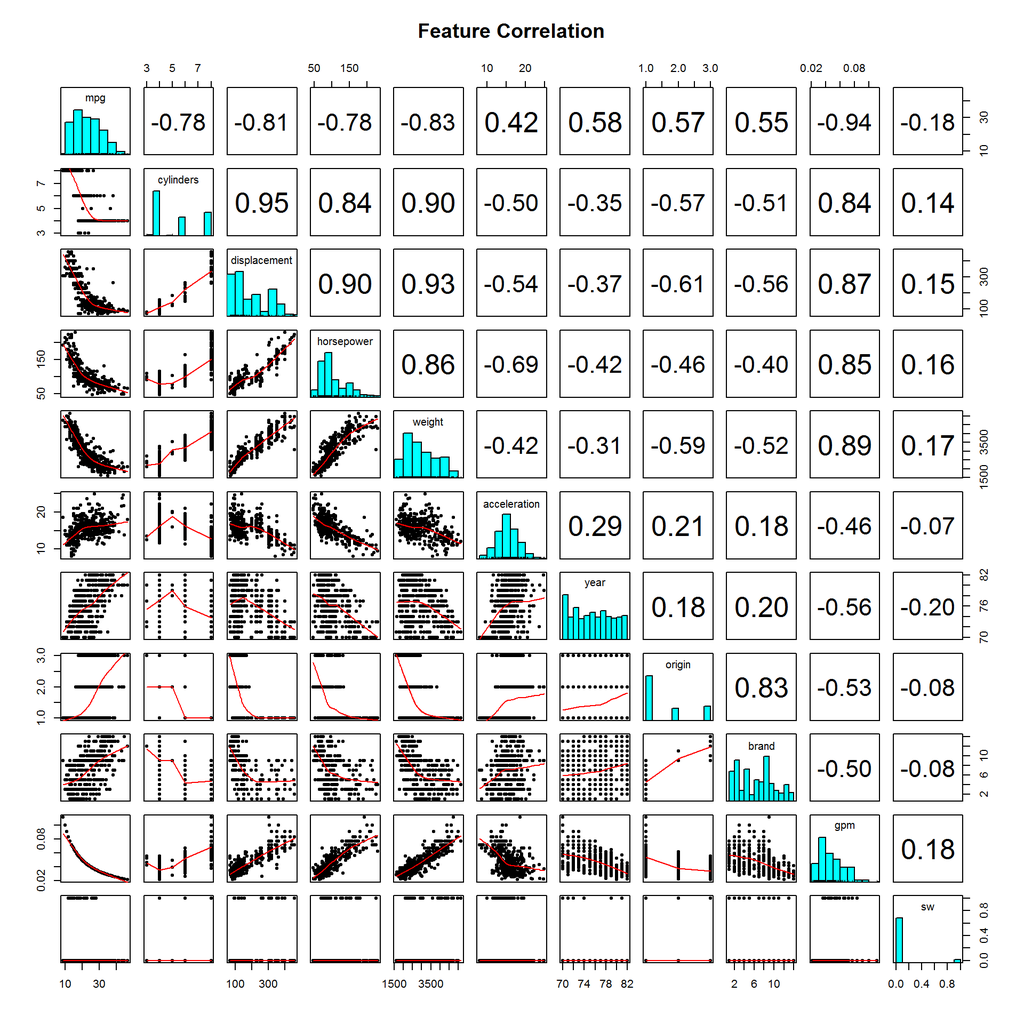

```r
pairs.panels(CarData[,-c(9,10)],density=F,ellipses=F,
             main="Feature Correlation")
```

From the correlation plot I found

1. **cylinder** is correlated with **mpg**, therefore this can be a useful variable for prediction.
2. **displacement** is also correlated with **mpg**, but it worthes notice that it’s highly correlated with **cylinder**. Multicollinearity might not be an issue in prediction, but it is trouble in interpretation.
3. **horsepower** and **weight** have similar case as **displacement**.
4. **acceleration** has a “purer” but weaker correlation with **mpg**, but it’s a potentially useful variable anyway.
5. **year** is also a useful variable since the fuel efficiency seems to evolve during those years. This pattern is more obvious when compared with **gpm**.
6. **origin** is definitely a useful variable because Japan has a significant advantage in fuel efficiency.
7. **brand** seems to be correlated with mpg, but this is doubious since the relation maybe caused by origin.
8. **sw** looks like a factor influencing mpg, but as the data is unbalanced, this needed to be further tested.

Next, I inspected some doubious correlation:

#### A. **brand**

I want to check whether mpg indeed varies by brands, or it just varies by origins.

```r
BrandPlot <- plot_ly(data=CarData, y = ~mpg, x=~brand,
                     color = ~origin, type = "box")%>%
             layout(title="MPG by Brands",
                    xaxis = list(title=""), yaxis =  list(title="MPG"))
BrandPlot
```

[interactive chart not shown]

All right, **brand** seems contribute no more information than origin, it can take a rest now.

#### B. **sw**

```r
t.test(CarData$mpg[CarData$sw==0],CarData$mpg[CarData$sw==1],
       var.equal = F)
```

```
##
##  Welch Two Sample t-test
##
## data:  CarData$mpg[CarData$sw == 0] and CarData$mpg[CarData$sw == 1]
## t = 5.1431, df = 36.963, p-value = 9.079e-06
## alternative hypothesis: true difference in means is not equal to 0
## 95 percent confidence interval:
##  3.346797 7.698258
## sample estimates:
## mean of x mean of y
##  23.84038  18.31786
```

Small p-value shows that sw make a difference in car mpg, indicating that it could be a useful variable.

Further, I want to check some interaction terms.

#### C. **year** x **origin**

Different origin may have a different evolution path, maybe American car catch up faster in fuel efficiency than European.

```r
YearPlot<- plot_ly(data=CarData, y = ~mpg, x=~jitter(year),
                   hoverinfo = 'text',
                   text=~paste('Brand: ',brand,
                               '</br> Name: ', capitalize(name),
                               '</br> MPG: ', mpg,
                               '</br> Displacement: ', displacement),
                   color = ~origin,type="scatter",mode="markers")%>%
           layout(title="MPG by Year",
                  xaxis = list(title="Year"),
                  yaxis =  list(title="MPG"))
YearPlot
```

[interactive chart not shown]

The hypothesis seems to find its evidence from this plot. American cars have a clearly lower **mpg** in 1970 but later their mpg is more compariable with Japanese cars.

#### D. **sw** x **origin**

Maybe state wagons with different origin have different fuel efficiency?

```r
aov.fit=aov(mpg~origin*sw,data=CarData)
summary(aov.fit)
```

```
##              Df Sum Sq Mean Sq F value   Pr(>F)
## origin        2   7904    3952  98.859  < 2e-16 ***
## sw            1    464     464  11.616 0.000723 ***
## origin:sw     2     19      10   0.238 0.788332
## Residuals   386  15431      40
## ---
## Signif. codes:  0 '***' 0.001 '**' 0.01 '*' 0.05 '.' 0.1 ' ' 1
```

The interaction term has a high p-value for the null hypothesis: it’s not useful.

#### E. **displacement** / **horsepower**

Some car designs focus on luxury experience, while others focus on economics. So this variable could be useful in distinguish whether a car is luxury car or not.

```r
luxPlot=plot_ly(data=CarData, y = ~mpg, x=~I(displacement/horsepower),
                   hoverinfo = 'text',
                   text=~paste('Brand: ',brand,
                               '</br> Name: ', capitalize(name),
                               '</br> MPG: ', mpg,
                               '</br> Displacement: ', displacement),
                   color=(~I(displacement/horsepower)>1.9),
                   type="scatter",mode="markers")%>%
        layout(title="Luxury vs Economics",
                  xaxis = list(title="Displacement/Horsepower ratio"),
                  yaxis =  list(title="MPG"))
luxPlot
```

[interactive chart not shown]

The pattern shows that those cars with **displacement/horsepower** > 1.9 seem to be luxury ones while the rest are more likely economic cars.

```r
CarData=mutate(CarData,luxury=(displacement/horsepower>1.9))
CarData=mutate(CarData,dhratio=displacement/horsepower)
```

#### F. General View

Finally, look at a big picture including all continuous variables

```r
ConPlot <- plot_ly(CarData, x = ~weight, y = ~horsepower, z = ~acceleration,size=~displacement, color = ~mpg) %>%
  add_markers() %>%
  layout(title="Global View",
         scene = list(xaxis = list(title = 'Weight'),
                      yaxis = list(title = 'Horsepower'),
                      zaxis = list(title = 'Acceleration')))
ConPlot
```

[interactive chart not shown]

Looks like no more interaction terms is obvious from this graph.

## 4. Train/Test Partition (Question 2.(c))

Seperate the data into training set and testing set. The partition ratio is 0.7, so there won’t be too few data in each side.

```r
Train.ind = createDataPartition(CarData$mpg, p=0.7, list=FALSE)
training = CarData[ Train.ind, ]
testing = CarData[ -Train.ind, ]
```

## 5. Model Fitting (Question 2.(d))

| Methods | Select | Reason |
| --- | --- | --- |
| Discriminant Analysis | No | Bad for Categorical Variables |
| KNN | No | Curse of Dimension |
| Decision Tree | No | Inferior to GBTree |
| Random Forests | No | Insufficient Features |
| LASSO regression | No | Inferior to Manual Variables Selection |
| Ridge regression | No | Inferior to Manual Variables Selection |
| Elastic Net Method | No | Inferior to Manual Variables Selection |
| Logistics | Yes | Best Traditional Model for Binary Prediction |
| GBTree | Yes | Good for Nonlinear Modeling |

#### A. Logistic Regression

Before fitting a logistics regression, I want to “cheat” a little bit here by fitting a linear regression to **mpg**, try all possible variables and plausible interaction terms there. Then use stepwise regression to perform variable selection, and use selected variables to fit a logistics regression.

```r
m1=lm(data=training,mpg~cylinders+displacement+horsepower+weight+acceleration+year+origin+sw+year*origin+sw*origin+I(displacement/horsepower)+luxury*displacement+luxury*sw+luxury*weight+luxury*cylinders)
summary(m1)
```

```
##
## Call:
## lm(formula = mpg ~ cylinders + displacement + horsepower + weight +
##     acceleration + year + origin + sw + year * origin + sw *
##     origin + I(displacement/horsepower) + luxury * displacement +
##     luxury * sw + luxury * weight + luxury * cylinders, data = training)
##
## Residuals:
##     Min      1Q  Median      3Q     Max
## -8.4593 -1.6639 -0.1327  1.5356 11.9323
##
## Coefficients:
##                              Estimate Std. Error t value Pr(>|t|)
## (Intercept)                 16.041632   8.128145   1.974 0.049504 *
## cylinders                    0.879783   0.585644   1.502 0.134265
## displacement                 0.088436   0.032614   2.712 0.007149 **
## horsepower                  -0.137387   0.053337  -2.576 0.010562 *
## weight                      -0.009157   0.001241  -7.380 2.21e-12 ***
## acceleration                 0.133028   0.116365   1.143 0.254026
## year                         0.494486   0.081634   6.057 4.91e-09 ***
## originEuropean             -49.731338  12.283354  -4.049 6.83e-05 ***
## originJapan                -39.215375  11.108544  -3.530 0.000492 ***
## swTRUE                      -1.151361   2.237221  -0.515 0.607249
## I(displacement/horsepower)  -6.450746   2.570097  -2.510 0.012694 *
## luxuryTRUE                  -7.526973   3.842810  -1.959 0.051232 .
## year:originEuropean          0.670459   0.159757   4.197 3.74e-05 ***
## year:originJapan             0.519527   0.142062   3.657 0.000310 ***
## originEuropean:swTRUE        1.710994   3.210771   0.533 0.594571
## originJapan:swTRUE           3.928874   3.192631   1.231 0.219599
## displacement:luxuryTRUE     -0.019259   0.018779  -1.026 0.306079
## swTRUE:luxuryTRUE            0.997898   2.392061   0.417 0.676903
## weight:luxuryTRUE            0.005077   0.001456   3.488 0.000573 ***
## cylinders:luxuryTRUE        -1.243588   0.767767  -1.620 0.106518
## ---
## Signif. codes:  0 '***' 0.001 '**' 0.01 '*' 0.05 '.' 0.1 ' ' 1
##
## Residual standard error: 3.012 on 256 degrees of freedom
## Multiple R-squared:  0.863,  Adjusted R-squared:  0.8529
## F-statistic: 84.91 on 19 and 256 DF,  p-value: < 2.2e-16
```

Most terms has a significant p value, some are not due to colinearity, which is not an issue in prediction scenario.

```r
m2=stepAIC(m1,direction = "both")
```

```r
summary(m2)
```

```
##
## Call:
## lm(formula = mpg ~ cylinders + displacement + horsepower + weight +
##     year + origin + I(displacement/horsepower) + luxury + year:origin +
##     weight:luxury + cylinders:luxury, data = training)
##
## Residuals:
##     Min      1Q  Median      3Q     Max
## -8.4184 -1.6369  0.0003  1.5013 11.9847
##
## Coefficients:
##                              Estimate Std. Error t value Pr(>|t|)
## (Intercept)                 1.501e+01  7.269e+00   2.065 0.039945 *
## cylinders                   1.229e+00  4.689e-01   2.622 0.009265 **
## displacement                6.911e-02  2.596e-02   2.662 0.008259 **
## horsepower                 -1.409e-01  5.012e-02  -2.812 0.005291 **
## weight                     -7.991e-03  9.903e-04  -8.069 2.56e-14 ***
## year                        5.017e-01  7.880e-02   6.366 8.64e-10 ***
## originEuropean             -4.834e+01  1.184e+01  -4.081 5.96e-05 ***
## originJapan                -3.441e+01  1.057e+01  -3.256 0.001279 **
## I(displacement/horsepower) -5.778e+00  2.486e+00  -2.324 0.020896 *
## luxuryTRUE                 -5.300e+00  3.485e+00  -1.521 0.129580
## year:originEuropean         6.515e-01  1.545e-01   4.217 3.42e-05 ***
## year:originJapan            4.586e-01  1.357e-01   3.379 0.000837 ***
## weight:luxuryTRUE           4.138e-03  1.212e-03   3.416 0.000737 ***
## cylinders:luxuryTRUE       -1.829e+00  5.811e-01  -3.146 0.001843 **
## ---
## Signif. codes:  0 '***' 0.001 '**' 0.01 '*' 0.05 '.' 0.1 ' ' 1
##
## Residual standard error: 3.001 on 262 degrees of freedom
## Multiple R-squared:  0.8608, Adjusted R-squared:  0.8539
## F-statistic: 124.6 on 13 and 262 DF,  p-value: < 2.2e-16
```

```r
m3=glm(mpg_binary~cylinders+displacement+horsepower+weight+
         acceleration+year+origin,
       family=binomial(logit),data=training)

summary(m3)
```

```
##
## Call:
## glm(formula = mpg_binary ~ cylinders + displacement + horsepower +
##     weight + acceleration + year + origin, family = binomial(logit),
##     data = training)
##
## Deviance Residuals:
##      Min        1Q    Median        3Q       Max
## -2.19201  -0.08440  -0.00022   0.14803   2.01016
##
## Coefficients:
##                  Estimate Std. Error z value Pr(>|z|)
## (Intercept)    -28.517996   8.069617  -3.534 0.000409 ***
## cylinders        0.380422   0.594448   0.640 0.522199
## displacement    -0.003226   0.020423  -0.158 0.874495
## horsepower      -0.036621   0.031196  -1.174 0.240437
## weight          -0.006143   0.001854  -3.314 0.000919 ***
## acceleration    -0.079110   0.169490  -0.467 0.640675
## year             0.639512   0.124433   5.139 2.76e-07 ***
## originEuropean   1.114241   0.926576   1.203 0.229156
## originJapan     -0.045589   0.918252  -0.050 0.960403
## ---
## Signif. codes:  0 '***' 0.001 '**' 0.01 '*' 0.05 '.' 0.1 ' ' 1
##
## (Dispersion parameter for binomial family taken to be 1)
##
##     Null deviance: 381.907  on 275  degrees of freedom
## Residual deviance:  98.794  on 267  degrees of freedom
## AIC: 116.79
##
## Number of Fisher Scoring iterations: 8
```

```r
m4=glm(mpg_binary~cylinders+displacement+horsepower+weight+
         acceleration+year+origin+I(displacement/horsepower)+
         luxury+year*origin+displacement*luxury+
         weight*luxury+cylinders*luxury,
       family=binomial(logit),data=training)
summary(m4)
```

```
##
## Call:
## glm(formula = mpg_binary ~ cylinders + displacement + horsepower +
##     weight + acceleration + year + origin + I(displacement/horsepower) +
##     luxury + year * origin + displacement * luxury + weight *
##     luxury + cylinders * luxury, family = binomial(logit), data = training)
##
## Deviance Residuals:
##      Min        1Q    Median        3Q       Max
## -2.25582  -0.00126   0.00000   0.09383   1.60954
##
## Coefficients:
##                              Estimate Std. Error z value Pr(>|z|)
## (Intercept)                -58.408499  22.481564  -2.598 0.009375 **
## cylinders                    0.653669   0.840259   0.778 0.436606
## displacement                -0.065733   0.098643  -0.666 0.505174
## horsepower                   0.114905   0.136499   0.842 0.399897
## weight                      -0.011119   0.003041  -3.656 0.000256 ***
## acceleration                -0.320922   0.214427  -1.497 0.134485
## year                         0.978259   0.259473   3.770 0.000163 ***
## originEuropean              43.543175  22.170793   1.964 0.049531 *
## originJapan                 37.738222  20.283920   1.860 0.062815 .
## I(displacement/horsepower)  10.204401   8.303187   1.229 0.219082
## luxuryTRUE                 -27.300236  11.064810  -2.467 0.013614 *
## year:originEuropean         -0.573285   0.298019  -1.924 0.054398 .
## year:originJapan            -0.508036   0.272010  -1.868 0.061803 .
## displacement:luxuryTRUE     -0.294888   0.136512  -2.160 0.030760 *
## weight:luxuryTRUE            0.016953   0.004990   3.397 0.000680 ***
## cylinders:luxuryTRUE         5.416870   3.708299   1.461 0.144086
## ---
## Signif. codes:  0 '***' 0.001 '**' 0.01 '*' 0.05 '.' 0.1 ' ' 1
##
## (Dispersion parameter for binomial family taken to be 1)
##
##     Null deviance: 381.907  on 275  degrees of freedom
## Residual deviance:  72.636  on 260  degrees of freedom
## AIC: 104.64
##
## Number of Fisher Scoring iterations: 11
```

```r
m5=glm(mpg_binary~displacement+weight+
         year+origin+
         luxury+year*origin+displacement*luxury+
         weight*luxury,
       family=binomial(logit),data=training)
summary(m5)
```

```
##
## Call:
## glm(formula = mpg_binary ~ displacement + weight + year + origin +
##     luxury + year * origin + displacement * luxury + weight *
##     luxury, family = binomial(logit), data = training)
##
## Deviance Residuals:
##      Min        1Q    Median        3Q       Max
## -2.31170  -0.03865  -0.00012   0.13131   2.73499
##
## Coefficients:
##                           Estimate Std. Error z value Pr(>|z|)
## (Intercept)             -39.895099  12.458916  -3.202  0.00136 **
## displacement              0.047607   0.024251   1.963  0.04964 *
## weight                   -0.010276   0.002468  -4.164 3.12e-05 ***
## year                      0.806828   0.192883   4.183 2.88e-05 ***
## originEuropean           28.691395  18.303346   1.568  0.11699
## originJapan              23.322905  16.821829   1.386  0.16560
## luxuryTRUE              -12.105121   6.303275  -1.920  0.05480 .
## year:originEuropean      -0.368092   0.243742  -1.510  0.13100
## year:originJapan         -0.311487   0.223360  -1.395  0.16315
## displacement:luxuryTRUE  -0.111611   0.037777  -2.955  0.00313 **
## weight:luxuryTRUE         0.010622   0.003434   3.093  0.00198 **
## ---
## Signif. codes:  0 '***' 0.001 '**' 0.01 '*' 0.05 '.' 0.1 ' ' 1
##
## (Dispersion parameter for binomial family taken to be 1)
##
##     Null deviance: 381.907  on 275  degrees of freedom
## Residual deviance:  83.703  on 265  degrees of freedom
## AIC: 105.7
##
## Number of Fisher Scoring iterations: 9
```

```r
anova(m3,m4,test="Chisq")
```

```
## Analysis of Deviance Table
##
## Model 1: mpg_binary ~ cylinders + displacement + horsepower + weight +
##     acceleration + year + origin
## Model 2: mpg_binary ~ cylinders + displacement + horsepower + weight +
##     acceleration + year + origin + I(displacement/horsepower) +
##     luxury + year * origin + displacement * luxury + weight *
##     luxury + cylinders * luxury
##   Resid. Df Resid. Dev Df Deviance Pr(>Chi)
## 1       267     98.794
## 2       260     72.636  7   26.158 0.000472 ***
## ---
## Signif. codes:  0 '***' 0.001 '**' 0.01 '*' 0.05 '.' 0.1 ' ' 1
```

```r
anova(m3,m5,test="Chisq")
```

```
## Analysis of Deviance Table
##
## Model 1: mpg_binary ~ cylinders + displacement + horsepower + weight +
##     acceleration + year + origin
## Model 2: mpg_binary ~ displacement + weight + year + origin + luxury +
##     year * origin + displacement * luxury + weight * luxury
##   Resid. Df Resid. Dev Df Deviance  Pr(>Chi)
## 1       267     98.794
## 2       265     83.703  2   15.091 0.0005284 ***
## ---
## Signif. codes:  0 '***' 0.001 '**' 0.01 '*' 0.05 '.' 0.1 ' ' 1
```

```r
mpg_fit=predict(m4,newdata = testing,type="response")
mpg_test=as.logical(testing$mpg_binary)
confusionMatrix(data=(mpg_fit>0.5),reference = mpg_test)
```

```
## Confusion Matrix and Statistics
##
##           Reference
## Prediction FALSE TRUE
##      FALSE    52    6
##      TRUE      8   50
##
##                Accuracy : 0.8793
##                  95% CI : (0.8058, 0.9324)
##     No Information Rate : 0.5172
##     P-Value [Acc > NIR] : <2e-16
##
##                   Kappa : 0.7586
##  Mcnemar's Test P-Value : 0.7893
##
##             Sensitivity : 0.8667
##             Specificity : 0.8929
##          Pos Pred Value : 0.8966
##          Neg Pred Value : 0.8621
##              Prevalence : 0.5172
##          Detection Rate : 0.4483
##    Detection Prevalence : 0.5000
##       Balanced Accuracy : 0.8798
##
##        'Positive' Class : FALSE
##
```

```r
roc.fit=roc(mpg_test~mpg_fit);roc.fit
```

```
##
## Call:
## roc.formula(formula = mpg_test ~ mpg_fit)
##
## Data: mpg_fit in 60 controls (mpg_test FALSE) < 56 cases (mpg_test TRUE).
## Area under the curve: 0.9601
```

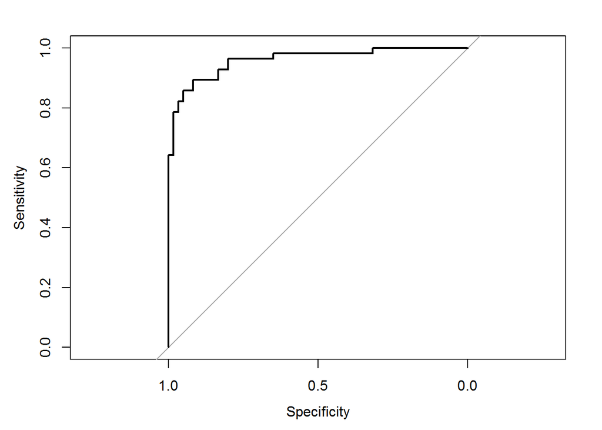

```r
plot.roc(roc.fit)
```

#### B. Gradient Boosting Trees

Use Caret to tune parameters.

```r
n.trees=c(120,140,160)
interaction.depth=c(3,4,5,6)
shrinkage=c(0.01,0.02,0.05,0.1)
n.minobsinnode=c(5,10,15)

para=expand.grid(n.trees=n.trees,
                 interaction.depth=interaction.depth,
                 shrinkage=shrinkage,
                 n.minobsinnode=n.minobsinnode)

m6=train(factor(mpg_binary)~cylinders+displacement+horsepower+weight+
         acceleration+year+origin+sw+dhratio,
         data=training,method="gbm",tuneGrid=para)
```

Indeed I ran the train() function several times before and found the close region for parameters. The procedure showed above is just the last step. Also, since tree is good at modeling nonlinear relation, I don’t need to include interaction terms.

```r
m6.fit=m6$finalModel

mpg_fit=predict(m6.fit,newdata =
                  testing[,c(2,3,4,5,6,7,8,13,15)],n.trees=80)
mpg_test=as.logical(testing$mpg_binary)
confusionMatrix(data=(mpg_fit<0.5),reference = mpg_test)
```

```
## Confusion Matrix and Statistics
##
##           Reference
## Prediction FALSE TRUE
##      FALSE    51    2
##      TRUE      9   54
##
##                Accuracy : 0.9052
##                  95% CI : (0.8367, 0.9517)
##     No Information Rate : 0.5172
##     P-Value [Acc > NIR] : < 2e-16
##
##                   Kappa : 0.8109
##  Mcnemar's Test P-Value : 0.07044
##
##             Sensitivity : 0.8500
##             Specificity : 0.9643
##          Pos Pred Value : 0.9623
##          Neg Pred Value : 0.8571
##              Prevalence : 0.5172
##          Detection Rate : 0.4397
##    Detection Prevalence : 0.4569
##       Balanced Accuracy : 0.9071
##
##        'Positive' Class : FALSE
##
```

```r
roc.fit=roc(mpg_test~mpg_fit);roc.fit
```

```
##
## Call:
## roc.formula(formula = mpg_test ~ mpg_fit)
##
## Data: mpg_fit in 60 controls (mpg_test FALSE) > 56 cases (mpg_test TRUE).
## Area under the curve: 0.9804
```

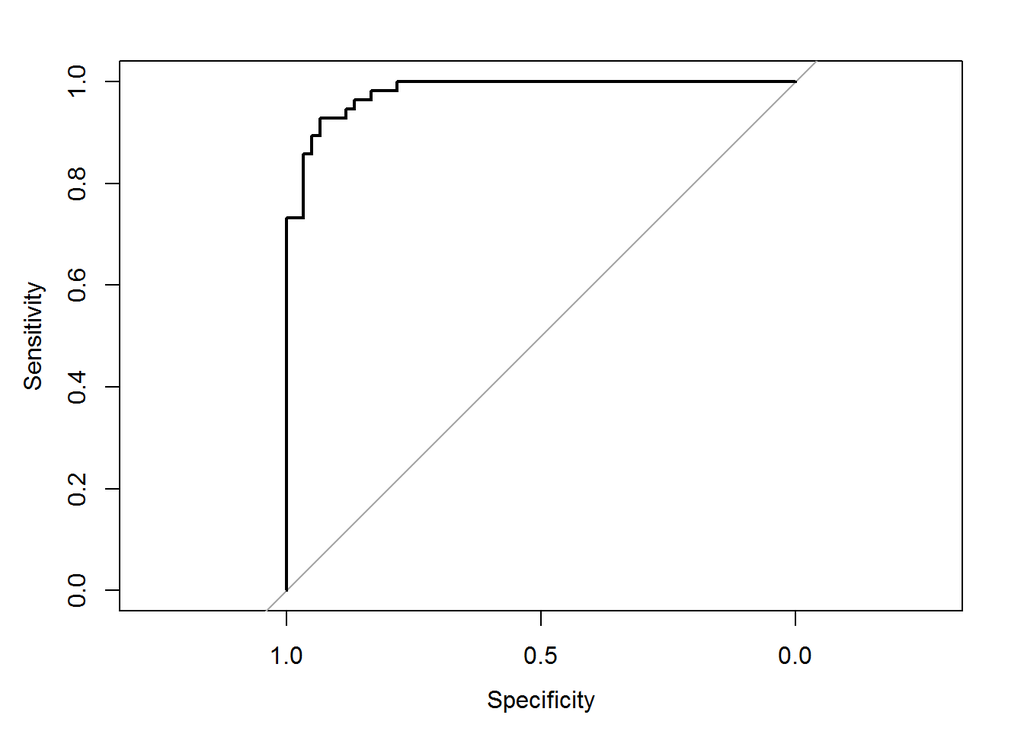

```r
plot.roc(roc.fit)
```